# The Reverse-Heading Maneuver

## Nature and value of the maneuver

The reverse-heading maneuver consists of a pair of flight legs of the same duration that are flown on opposing headings, preferably along the wind. Uniform wind conditions are desirable, and these are more likely present when flying along isobars or approximately along the wind. The maneuver should be flown in a drifting reference frame; that is, 2–5 min on one heading and then 2–5 min on a reverse heading. The heading reversal could be done using a 90-270 turn or a teardrop pattern in order to return to the end of the first leg at the start of the second leg, but it can also be flown with a simple 180-degree turn to return along a path slightly offset from the first. The maneuver should not be reverse-course; if there is a side wind it should drift with that wind while maintaining a constant heading, and it is best if the legs are displaced from each other in distance as would correspond to similar drift during the heading-reversal maneuver.

## An example

A representative good reverse-heading maneuver was flown during flight 1 of the ARISTO2017 project, as shown in Fig. 1.

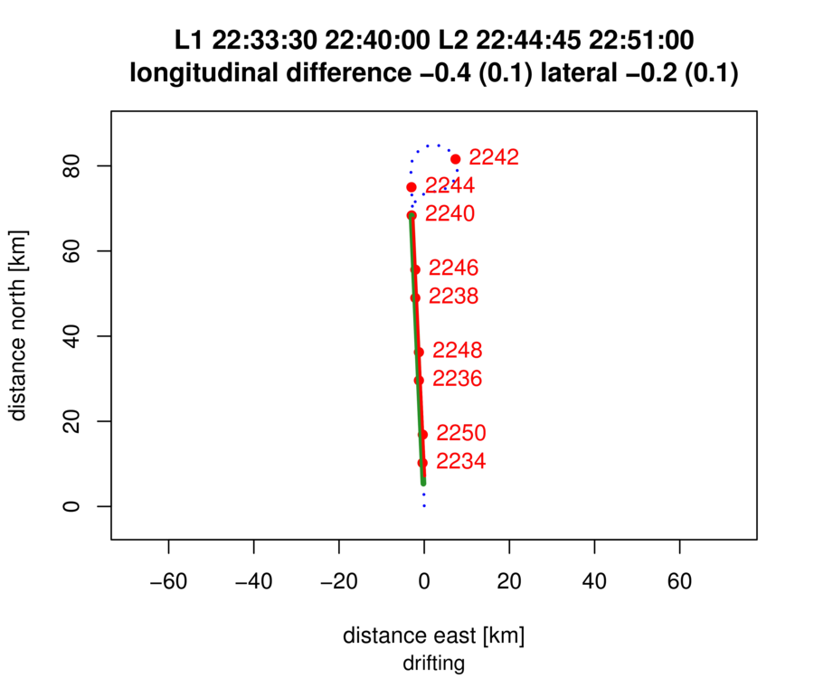

Figure 1: Reverse-heading maneuver from the ARISTO2017 project, flight 1. The flight track is shown in a reference frame drifting with the wind in order to highlight the overlap between the two flight legs. The selected periods, listed in the plot title, are shown as heavy red (northbound) or green (southbound) lines. The blue dotted portion of the flight track is not included in the comparison.

The longitudinal and lateral components of the wind are respectively

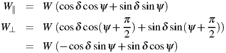

where **W** is the wind speed, **δ** the wind direction, and **ψ** the mean heading along the flight leg.

As in the QA tool, the plot title includes half of the two differences between the legs and (in parentheses) the standard deviations in the means for these two differences. Half the difference is listed because this is the best estimate of the measurement error, if that error arises from the same offset applied in two different directions during the reverse-heading maneuver.

Figure 2 shows the longitudinal and lateral components of the horizontal wind for the two flight legs. The components for the second leg are reversed in sign and plotted in reverse time order starting at the end time for the first leg, so if the wind pattern in space stays constant during the interval of the maneuver these two legs should show the same structure even if there is some variation along the legs. For this maneuver, there is fairly consistent structure in the lateral component for the two legs but a little more variability in the longitudinal component, so this may account for the smaller estimated error in the lateral component in comparison to the longitudinal component.

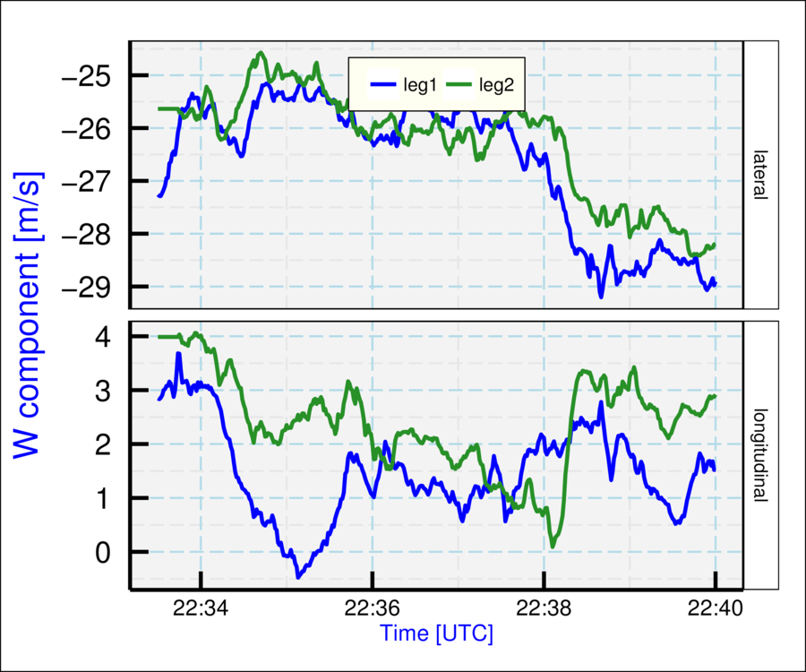

Figure 2: For the same maneuver as shown in the previous figure, the lateral and longitudinal wind components along the two legs. For the second leg, the components are reversed in sign and plotted in reverse sequence starting at the time that matches the end of the first leg, so if the wind remains consistent the two legs will show the same pattern.

## Using the QA tool

Select “Past Projects”, “Maneuver Study”, then “Reverse Heading.” When you select a project from the drop-down menu, the available reverse-heading maneuvers for that project will be displayed and you can select one for display. Initially, a drifting flight track for the maneuver will be displayed, but it will cover more than the straight legs and will not have the individual legs identified properly. You must do this using the “set interval” slider, which has two control dots that can be used to isolate the straight legs. Set the “set time for” drop-down menu to “leg 1” and move the slider buttons to specify the start and end of the first leg. As you move the buttons, a red line (possibly partially obscured by the leg-2 green line) will be displayed on the plot to show your selection. Then change the “set time for” menu to “leg 2” and use the slider buttons to specify the limits for the second flight leg, which should reasonably match the first in Lagrangian space. Once you do this, the plot title will show the time intervals selected and the error estimates obtained from half the sum of the average values for the two legs. If the wind conditions are steady, these should be approximately within the 0.4 m/s uncertainty estimate for components of the horizontal wind. Also shown in parentheses in the plot title are the corresponding estimated standard deviations in the means for the two components. This provides an indication of how steady the wind is during the maneuver.

There is another way to set the times for the legs that uses the “brush” feature. If you hold down the left mouse button while selecting a rectangular area that includes only the flight segments to be used for the two legs, the times for the two segments will be set into storage and the time display will update for the selected leg. This is a convenient way to select legs that overlap in a drifting reference frame. Once set, the new times for the legs can be saved in the database using the “save times” button discussed below, just as for times set using the slider.

Two other plots can be selected using the “plot” menu, “wind” (for a plot of the wind direction and speed for the maneuver, along with the heading), and “reverse time,” which produces a plot like Fig. 2 above. This plot shows the lateral and longitudinal components of the horizontal wind along the two legs, with the components for the second leg reversed in sign and plotted in reverse order so as to overlap the Lagrangian positions from the first leg. These plots can help indicate if the difference between legs appears to be systematic or is more likely attributable to natural variability in conditions along the flight tracks. A systematic offset with little variability is more likely to indicate a measurement problem than an offset that is small in comparison to the natural variability.

The bottom slider on the left side, labeled “SSRD offset [deg],” allows a user to see the effect of adding an offset to the sideslip (SSRD). As the slider is changed, the value displayed for the lateral-component difference will change, so that difference can be adjusted to zero by means of the slider. This can help assess if a change in the first SSRD sensitivity coefficient (determining the offset) is indicated by the maneuver. The imposed offset also affects the plot of the wind components shown when the “reverse time” item from the “plot” menu is selected.

Finally, two additional buttons are provided for editing the database of maneuvers. The ‘delete’ button removes the maneuver from the database (although the effect won’t be seen until you change projects or restart the Shiny app), and the ‘save times’ button saves the times selected for the maneuver to the database. This is useful if you want to see the maneuver in a later run without entering all the same start and stop times for the flight legs.

—- End of This Note —-